# 01_limpieza_normalizacion

```python
!pip install mapclassify
!pip install factor_analyzer
!pip install plotnine
```

```python
import pandas as pd
import numpy as np
import matplotlib.pyplot as plt
import plotly.express as px
import seaborn as sns
import plotnine
from plotnine import *
from sklearn.decomposition import PCA


import warnings
warnings.filterwarnings("ignore")

pd.set_option("display.max_rows", None, "display.max_columns", None)
```

```python
path = '00_lectura_datos.csv'

df = pd.read_csv(path)
```

## Cambiar nombres de variables

Estandarizar nombres de las variables

```python
df.columns = df.columns.str.lower() \
                       .str.replace(' ', '_') \
                       .str.replace('[^\w\s]', '', regex=True)
```

```python
df.info()
```

```
<class 'pandas.core.frame.DataFrame'>
RangeIndex: 242 entries, 0 to 241
Data columns (total 49 columns):
 #   Column                                                           Non-Null Count  Dtype
---  ------                                                           --------------  -----
 0   country                                                          242 non-null    object
 1   nuts_code                                                        242 non-null    object
 2   regionname                                                       242 non-null    object
 3   infant_mortality                                                 242 non-null    float64
 4   satisfaction_with_water_quality                                  236 non-null    float64
 5   uncollected_sewage                                               242 non-null    float64
 6   sewage_treatment_additional                                      242 non-null    float64
 7   safety_at_night                                                  236 non-null    float64
 8   money_stolen                                                     236 non-null    float64
 9   assaultedmugged                                                  236 non-null    float64
```

[output cut: 41 more lines]

Cambiar el nombre de algunas variables

```python
df.rename(columns={
    'regionname': 'region',
    'satisfaction_with_water_quality': 'satisfaction_water_quality',
    'digital_skills_above_basic_level': 'digital_skills_above_basic',
    'online_interaction_with_public_authorities': 'online_interaction_public_authorities',
    'freedom_of_media': 'freedom_media',
    'index_of_positive_emotions': 'positive_emotions',
    'trust_in_the_national_government': 'trust_national_government',
    'trust_in_the_legal_system': 'trust_legal_system',
    'trust_in_the_police': 'trust_police',
    'voiced_opinion_to_public_official': 'voiced_opinion',
    'female_participation_in_regional_assemblies': 'female_participation',
    'institution_quality_index': 'institution_quality',
    'freedom_over_life_choices': 'freedom_life_choices',
    'job_opportunities': 'job_opp',
    'institution_impartiality_index_eqi': 'institution_impartiality',
    'tolerance_towards_immigrants': 'tt_immigrants',
    'tolerance_towards_minorities': 'tt_minorities',
    'tolerance_towards__gay_or_lesbian_people': 'tt_lgtb',
    'women_treated_with_respect': 'women_respect',
    'tertiary_education_attainment': 'tertiary_education',
    'academic_citations_per_1000_persons_': 'academic_citations',
    'sewage_treatment_additional': 'sewage_treatment',
    'assaultedmugged': 'assaulted',
    'share_of_lowachieving_15_year_olds_in_reading_level_1a_or_lower': 'low_achieving_reading_level',
    'share_of_lowachieving_15_year_olds_in_maths_and_science': 'low_achieving_maths_science',
    'lowersecondary_completion_only': 'lower_secondary_only',
    'standardised_cancer_death_rate': 'cancer_death',
    'standardised_heart_disease_death_rate': 'heart_death',
    'years_of_life_lost_due_to_air_pollution': 'years_life_lost_pollution',
    'air_pollution_no2': 'pollution_no2',
    'air_pollution_ozone_somo35': 'pollution_somo35',
    'air_pollution_pm25': 'pollution_pm25',
    'young_people_not_in_education_employment_or_training_neet': 'young_people_neet',
    'institutions_corruption_index_eqi': 'institutions_corruption'

}, inplace=True)
```

```python
df.info()
```

```
<class 'pandas.core.frame.DataFrame'>
RangeIndex: 242 entries, 0 to 241
Data columns (total 49 columns):
 #   Column                                 Non-Null Count  Dtype
---  ------                                 --------------  -----
 0   country                                242 non-null    object
 1   nuts_code                              242 non-null    object
 2   region                                 242 non-null    object
 3   infant_mortality                       242 non-null    float64
 4   satisfaction_water_quality             236 non-null    float64
 5   uncollected_sewage                     242 non-null    float64
 6   sewage_treatment                       242 non-null    float64
 7   safety_at_night                        236 non-null    float64
 8   money_stolen                           236 non-null    float64
 9   assaulted                              236 non-null    float64
```

[output cut: 41 more lines]

## Imputación de datos perdidos

```python
nan_count = df.isnull().sum()

nan_percentage = round((nan_count / len(df)) * 100, 2)

nan_summary = pd.DataFrame({
    'indicador': nan_count.index,
    'missing': nan_count.values,
    'proporcion': nan_percentage.values
})

nan_summary = nan_summary[nan_summary['missing'] > 0]

nan_summary
```

|  | indicador | missing | proporcion |
| --- | --- | --- | --- |
| 4 | satisfaction_water_quality | 6 | 2.48 |
| 7 | safety_at_night | 6 | 2.48 |
| 8 | money_stolen | 6 | 2.48 |
| 9 | assaulted | 6 | 2.48 |
| 11 | low_achieving_reading_level | 19 | 7.85 |
| 13 | lower_secondary_only | 1 | 0.41 |
| 14 | early_school_leavers | 5 | 2.07 |
| 15 | broadband_at_home | 1 | 0.41 |
| 16 | digital_skills_above_basic | 6 | 2.48 |
| 17 | online_interaction_public_authorities | 1 | 0.41 |
| 18 | internet_access | 6 | 2.48 |
| 19 | freedom_media | 6 | 2.48 |
| 20 | subjective_health_status | 6 | 2.48 |
| 23 | years_life_lost_pollution | 8 | 3.31 |
| 24 | positive_emotions | 6 | 2.48 |
| 25 | pollution_no2 | 8 | 3.31 |
| 26 | pollution_somo35 | 8 | 3.31 |
| 27 | pollution_pm25 | 8 | 3.31 |
| 28 | bathing_water_quality | 26 | 10.74 |
| 29 | trust_national_government | 6 | 2.48 |
| 30 | trust_legal_system | 6 | 2.48 |
| 31 | trust_police | 6 | 2.48 |
| 32 | voiced_opinion | 6 | 2.48 |
| 34 | institution_quality | 2 | 0.83 |
| 35 | freedom_life_choices | 6 | 2.48 |
| 36 | job_opp | 6 | 2.48 |
| 38 | young_people_neet | 4 | 1.65 |
| 39 | institutions_corruption | 2 | 0.83 |
| 40 | institution_impartiality | 2 | 0.83 |
| 41 | tt_immigrants | 6 | 2.48 |
| 42 | tt_minorities | 6 | 2.48 |
| 43 | tt_lgtb | 6 | 2.48 |
| 44 | women_respect | 6 | 2.48 |
| 46 | lifelong_learning | 1 | 0.41 |
| 47 | academic_citations | 4 | 1.65 |

```python
filtered_df = df[['country', 'bathing_water_quality', 'low_achieving_reading_level']]

grouped_df = filtered_df.groupby('country')

nan_summary_list = []

for name, group in grouped_df:
    nan_count = group.isnull().sum()
    nan_percentage = round((nan_count / len(group)) * 100, 2)

    nan_summary = pd.DataFrame({
        'country': name,
        'indicador': nan_count.index,
        'missing': nan_count.values,
        'proporcion': nan_percentage.values
    })

    nan_summary_list.append(nan_summary)

nan_summary_final = pd.concat(nan_summary_list)
nan_summary_final = nan_summary_final[nan_summary_final['missing'] > 0]

nan_summary_final
```

|  | country | indicador | missing | proporcion |
| --- | --- | --- | --- | --- |
| 1 | BE | bathing_water_quality | 4 | 36.36 |
| 1 | BG | bathing_water_quality | 4 | 66.67 |
| 1 | CZ | bathing_water_quality | 1 | 12.50 |
| 1 | DE | bathing_water_quality | 2 | 5.26 |
| 1 | EL | bathing_water_quality | 1 | 7.69 |
| 1 | ES | bathing_water_quality | 1 | 5.26 |
| 2 | ES | low_achieving_reading_level | 19 | 100.00 |
| 1 | HR | bathing_water_quality | 1 | 25.00 |
| 1 | HU | bathing_water_quality | 1 | 12.50 |
| 1 | IT | bathing_water_quality | 1 | 4.76 |
| 1 | RO | bathing_water_quality | 7 | 87.50 |
| 1 | SE | bathing_water_quality | 1 | 12.50 |
| 1 | SK | bathing_water_quality | 2 | 50.00 |

```python
missing_all_by_country = {}

# Obtener la lista de países únicos
paises = df['country'].unique()

# Iterar sobre cada país
for pais in paises:
    # Filtrar el DataFrame por el país actual
    df_pais = df[df['country'] == pais]

    # Encontrar las variables con todos los datos perdidos para este país
    variables_con_todos_perdidos = df_pais.columns[df_pais.isnull().all()].tolist()

    # Guardar el resultado en el diccionario
    missing_all_by_country[pais] = variables_con_todos_perdidos

# Mostrar el resultado
for pais, variables in missing_all_by_country.items():
    print(f"País: {pais}, Variables con todos los datos perdidos: {variables}")
```

```
País: AT, Variables con todos los datos perdidos: []
País: BE, Variables con todos los datos perdidos: []
País: BG, Variables con todos los datos perdidos: []
País: CY, Variables con todos los datos perdidos: ['digital_skills_above_basic']
País: CZ, Variables con todos los datos perdidos: []
País: DE, Variables con todos los datos perdidos: []
País: DK, Variables con todos los datos perdidos: []
País: EE, Variables con todos los datos perdidos: ['digital_skills_above_basic']
País: EL, Variables con todos los datos perdidos: []
País: ES, Variables con todos los datos perdidos: ['low_achieving_reading_level']
País: FI, Variables con todos los datos perdidos: []
País: FR, Variables con todos los datos perdidos: []
País: HR, Variables con todos los datos perdidos: []
País: HU, Variables con todos los datos perdidos: []
País: IE, Variables con todos los datos perdidos: []
País: IT, Variables con todos los datos perdidos: []
País: LT, Variables con todos los datos perdidos: []
País: LU, Variables con todos los datos perdidos: ['digital_skills_above_basic']
País: LV, Variables con todos los datos perdidos: ['digital_skills_above_basic']
País: MT, Variables con todos los datos perdidos: ['digital_skills_above_basic']
País: NL, Variables con todos los datos perdidos: []
País: PL, Variables con todos los datos perdidos: []
País: PT, Variables con todos los datos perdidos: []
País: RO, Variables con todos los datos perdidos: []
País: SE, Variables con todos los datos perdidos: []
País: SI, Variables con todos los datos perdidos: []
País: SK, Variables con todos los datos perdidos: []
```

Indicadores con todos los datos perdidos en algún pais:

- digital_skills_above_basic:
  - CY: Chipre
  - EE: Estonia
  - LU: Luxemburgo
  - LV: Letonia
  - MT: Malta
- low_achieving_reading_level: ES = España

Para estos paises/indicadores no nos queda mas remedio que imputar por la media de toda la UE, a pesar de que son regiones muy diversas.

Imputaremos por pasos:

- Creamos unas listas

```python
num_cols = df.select_dtypes(include=['float64', 'int64']).columns.tolist()
indicadores_excl = ['digital_skills_above_basic', 'low_achieving_reading_level' ]
paises_excl = ['CY', 'EE', 'LU', 'LV', 'MT']
```

- Imputar valores perdidos, dejando a parte los paises donde encontramos alguna variable completamente vacía

```python
# Imputación por país
for indicador in num_cols:
  df.loc[~df['country'].isin(paises_excl), indicador] = df.groupby('country')[indicador].transform(lambda x: x.fillna(x.mean()))
```

```python
num_cols = df.select_dtypes(include=['float64', 'int64']).columns.tolist()
num_cols = [col for col in num_cols if col not in indicadores_excl]

for indicador in num_cols:
    df.loc[~df['country'].isin(paises_excl), indicador] = df.groupby('country')[indicador].transform(lambda x: x.fillna(x.mean()))
```

Finalmente nos quedara por imputar `'digital_skills_above_basic', 'low_achieving_reading_level'` en los paises donde se encuentran completamente vacías:

- Vamos a imputarlas por la media global de todos los paises:

```python
num_cols = df.select_dtypes(include=['float64', 'int64']).columns.tolist()

for col in num_cols:
    df[col].fillna(df[col].mean(), inplace=True)
```

```python
nan_count = df.isnull().sum()

nan_percentage = round((nan_count / len(df)) * 100, 2)

nan_summary = pd.DataFrame({
    'indicador': nan_count.index,
    'missing': nan_count.values,
    'proporcion': nan_percentage.values
})

nan_summary = nan_summary[nan_summary['missing'] > 0]

nan_summary
```

|  | indicador | missing | proporcion |
| --- | --- | --- | --- |

```python
round(df.describe(),2)
```

|  | infant_mortality | satisfaction_water_quality | uncollected_sewage | sewage_treatment | safety_at_night | money_stolen | assaulted | traffic_deaths | low_achieving_reading_level | low_achieving_maths_science | lower_secondary_only | early_school_leavers | broadband_at_home | digital_skills_above_basic | online_interaction_public_authorities | internet_access | freedom_media | subjective_health_status | cancer_death | heart_death | years_life_lost_pollution | positive_emotions | pollution_no2 | pollution_somo35 | pollution_pm25 | bathing_water_quality | trust_national_government | trust_legal_system | trust_police | … |
| --- | --- | --- | --- | --- | --- | --- | --- | --- | --- | --- | --- | --- | --- | --- | --- | --- | --- | --- | --- | --- | --- | --- | --- | --- | --- | --- | --- | --- | --- | --- |
| count | 242.00 | 242.00 | 242.00 | 242.00 | 242.00 | 242.00 | 242.00 | 242.00 | 242.00 | 242.00 | 242.00 | 242.00 | 242.00 | 242.00 | 242.00 | 242.00 | 242.00 | 242.00 | 242.00 | 242.00 | 242.00 | 242.00 | 242.00 | 242.00 | 242.00 | 242.00 | 242.00 | 242.00 | 242.00 | … |
| mean | 3.21 | 82.38 | 2.40 | 84.30 | 75.55 | 8.05 | 3.16 | 48.38 | 22.91 | 45.24 | 19.70 | 9.57 | 89.52 | 26.83 | 60.17 | 89.51 | 72.38 | 68.09 | 78.71 | 47.12 | 542.92 | 71.74 | 12.84 | 4183.52 | 10.81 | 0.78 | 44.46 | 56.69 | 79.28 | … |
| std | 1.45 | 9.31 | 7.91 | 23.34 | 7.58 | 2.76 | 1.83 | 24.06 | 6.70 | 9.01 | 11.41 | 4.41 | 5.01 | 9.97 | 20.18 | 7.14 | 16.49 | 7.36 | 18.71 | 32.13 | 401.50 | 4.63 | 4.35 | 1395.22 | 3.56 | 0.21 | 14.61 | 15.94 | 8.46 | … |
| min | 0.00 | 43.41 | 0.00 | 0.00 | 55.53 | 1.84 | 0.57 | 0.00 | 11.05 | 31.01 | 1.50 | 1.43 | 73.50 | 6.88 | 10.46 | 62.33 | 28.85 | 25.22 | 46.32 | 18.02 | 0.00 | 56.10 | 0.30 | 1524.81 | 3.64 | 0.05 | 6.47 | 9.93 | 46.14 | … |
| 25% | 2.30 | 77.16 | 0.00 | 79.33 | 71.21 | 6.12 | 1.55 | 32.00 | 20.69 | 40.67 | 12.30 | 6.35 | 86.74 | 20.49 | 46.02 | 87.39 | 64.78 | 64.48 | 66.58 | 26.10 | 267.95 | 68.22 | 10.35 | 3208.65 | 8.59 | 0.68 | 35.22 | 45.11 | 77.10 | … |
| 50% | 3.00 | 83.25 | 0.00 | 95.71 | 75.63 | 7.87 | 2.85 | 43.00 | 21.10 | 42.36 | 17.50 | 8.68 | 89.69 | 23.61 | 61.94 | 90.71 | 76.03 | 68.18 | 74.85 | 34.30 | 394.69 | 73.03 | 12.44 | 4039.72 | 9.96 | 0.85 | 43.22 | 56.73 | 81.66 | … |
| 75% | 3.70 | 88.77 | 0.00 | 99.46 | 80.91 | 9.93 | 4.44 | 60.00 | 23.62 | 49.14 | 25.58 | 12.25 | 92.50 | 32.69 | 76.58 | 94.36 | 84.52 | 73.18 | 86.49 | 54.03 | 765.70 | 74.66 | 15.46 | 4887.95 | 12.89 | 0.92 | 55.98 | 70.65 | 84.14 | … |
| max | 9.70 | 99.91 | 55.56 | 100.00 | 92.74 | 15.13 | 8.14 | 159.00 | 47.10 | 71.05 | 58.70 | 26.03 | 100.00 | 52.53 | 94.35 | 99.73 | 98.09 | 81.20 | 147.60 | 179.74 | 1871.59 | 81.61 | 31.18 | 8620.22 | 23.24 | 1.00 | 84.88 | 91.16 | 92.30 | … |

## Consistencia del dataset

- **Test de esfericidad de Bartlett**.

Compara la matriz de correlaciones con una matriz identidad para extraer un p-valor. La hipótesis nula del contraste es H0: Matriz de correlaciones = Matriz identidad, por lo que nos interesa rechazarla.

Distribución chi cuadrado. El test nos da: (estadístico, p-valor)

```python
from factor_analyzer.factor_analyzer import calculate_bartlett_sphericity

calculate_bartlett_sphericity(df[num_cols])
```

```
(12691.989535851226, 0.0)
```

Dado que el valor p es muy cercano a cero, podemos concluir que hay suficiente evidencia para rechazar la hipótesis nula de independencia de las variables. Esto implica que las variables del conjunto de datos no son independientes entre sí, lo cual es una condición deseable para realizar un análisis de componentes principales (PCA)

- **KMO-MSA global y por variable**.

Índice de adecuación muestral o de Kaiser-Meyer-Olkin para comparar la correlación observada entre pares de variables y sus correspondientes correlaciones parciales (una vez eliminado el efecto de otras variables presentes). Buscamos valores superiores a 0.5 y cuanto más cercanos a 1, mejor.

```python
from factor_analyzer.factor_analyzer import calculate_kmo
calculate_kmo(df[num_cols])
```

```
(array([0.91113371, 0.94458057, 0.86198727, 0.86712125, 0.88333864,
        0.59146788, 0.54655575, 0.9226573 , 0.82794503, 0.8527216 ,
        0.67181132, 0.63337005, 0.78385411, 0.90035619, 0.88740845,
        0.92673913, 0.95432981, 0.49901718, 0.86717901, 0.8603572 ,
        0.86859518, 0.95773948, 0.77342207, 0.79239035, 0.84459341,
        0.81727664, 0.95375926, 0.92577344, 0.88774395, 0.85846325,
        0.92879998, 0.950274  , 0.9221148 , 0.89659565, 0.85294007,
        0.92123469, 0.91508718, 0.93882551, 0.87608969, 0.86447992,
        0.92366193, 0.92276547, 0.83738545, 0.90310549, 0.92506958,
        0.94788907]),
 0.889329841441318)
```

Valores bastante altos lo que es muy bueno

## Normalizacion

### Min-max Normalization

El indicador I está orientado **positivamente**:

- I_normalizado = 100 ⋅ $\frac{(I - I_{\text{min}})}{(I_{\text{max}} - I_{\text{min}})}$

El indicador I está orientado **negativamente**:

- I_normalizado = -100 ⋅ $\frac{(I - I_{\text{min}})}{(I_{\text{max}} - I_{\text{min}})}$ + 100

```python
positively_oriented = []
negatively_oriented = []
gdp_index = []
```

```python
positively_oriented = ['satisfaction_water_quality',
                       'safety_at_night',
                       'broadband_at_home',
                       'digital_skills_above_basic',
                       'online_interaction_public_authorities',
                       'internet_access',
                       'freedom_media',
                       'subjective_health_status',
                       'positive_emotions',
                       'bathing_water_quality',
                       'trust_national_government',
                       'trust_legal_system',
                       'trust_police',
                       'voiced_opinion',
                       'female_participation',
                       'institution_quality',
                       'freedom_life_choices',
                       'job_opp',
                       'institution_impartiality',
                       'tt_immigrants',
                       'tt_minorities',
                       'tt_lgtb',
                       'women_respect',
                       'tertiary_education',
                       'lifelong_learning',
                       'academic_citations',
                       'sewage_treatment'
                       ]
```

```python
negatively_oriented = ['infant_mortality',
                       'uncollected_sewage',
                       'money_stolen',
                       'assaulted',
                       'traffic_deaths',
                       'low_achieving_reading_level',
                       'low_achieving_maths_science',
                       'lower_secondary_only',
                       'early_school_leavers',
                       'cancer_death',
                       'heart_death',
                       'years_life_lost_pollution',
                       'pollution_no2',
                       'pollution_somo35',
                       'pollution_pm25',
                       'teenage_pregnancy',
                       'young_people_neet',
                       'institutions_corruption'
                       ]
```

```python
gdp_index = ['gdp_per_capita_2022']
```

```python
df_minmax = df.copy()
```

```python
# Función para la normalización min-max
def min_max_normalize(series, positive=True):
    min_val = series.min()
    max_val = series.max()
    if positive:
        return 100 * (series - min_val) / (max_val - min_val)
    else:
        return 100 - 100 * (series - min_val) / (max_val - min_val)
```

```python
# Aplicar la normalización min-max para indicadores positivos
for indicator in positively_oriented:
    df_minmax[indicator] = min_max_normalize(df[indicator], positive=True)

# Aplicar la normalización min-max para indicadores negativos
for indicator in negatively_oriented:
    df_minmax[indicator] = min_max_normalize(df[indicator], positive=False)

# Aplicar la normalización min-max para GDP
for indicator in gdp_index:
    df_minmax[indicator] = min_max_normalize(df[indicator], positive=True)
```

```python
df_minmax.head()
```

|  | country | nuts_code | region | infant_mortality | satisfaction_water_quality | uncollected_sewage | sewage_treatment | safety_at_night | money_stolen | assaulted | traffic_deaths | low_achieving_reading_level | low_achieving_maths_science | lower_secondary_only | early_school_leavers | broadband_at_home | digital_skills_above_basic | online_interaction_public_authorities | internet_access | freedom_media | subjective_health_status | cancer_death | heart_death | years_life_lost_pollution | positive_emotions | pollution_no2 | pollution_somo35 | pollution_pm25 | bathing_water_quality | … |
| --- | --- | --- | --- | --- | --- | --- | --- | --- | --- | --- | --- | --- | --- | --- | --- | --- | --- | --- | --- | --- | --- | --- | --- | --- | --- | --- | --- | --- | --- | --- |
| 0 | AT | AT11 | Burgenland | 72.164948 | 82.304997 | 100.0 | 98.700000 | 76.472210 | 48.362430 | 56.613786 | 83.018868 | 65.133157 | 72.779521 | 79.195804 | 66.802168 | 64.905660 | 58.339693 | 70.008344 | 72.775947 | 70.620323 | 81.522248 | 73.331359 | 90.823646 | 78.477908 | 81.372596 | 69.429199 | 46.670098 | 65.193576 | 94.722222 | … |
| 1 | AT | AT12 | Niederösterreich | 64.948454 | 82.304997 | 100.0 | 99.653143 | 76.472210 | 48.362430 | 56.613786 | 66.037736 | 65.133157 | 72.779521 | 79.720280 | 76.016260 | 64.905660 | 58.339693 | 76.004291 | 72.775947 | 70.620323 | 81.522248 | 77.813981 | 92.653970 | 80.826298 | 81.372596 | 66.833513 | 51.034658 | 68.145759 | 100.000000 | … |
| 2 | AT | AT13 | Wien | 62.886598 | 82.304997 | 100.0 | 99.800000 | 76.472210 | 48.362430 | 56.613786 | 94.968553 | 65.133157 | 72.779521 | 74.125874 | 61.517615 | 71.660377 | 58.339693 | 82.763142 | 72.775947 | 70.620323 | 81.522248 | 71.336888 | 89.654959 | 76.478170 | 81.372596 | 33.619009 | 52.088875 | 62.464952 | 93.790850 | … |
| 3 | AT | AT21 | Kärnten | 88.659794 | 81.952787 | 100.0 | 99.940591 | 85.282849 | 45.483977 | 28.116695 | 57.232704 | 65.133157 | 72.779521 | 84.615385 | 76.558266 | 60.301887 | 56.689386 | 68.267970 | 82.425644 | 78.704474 | 81.664549 | 78.524882 | 93.884492 | 81.625692 | 89.475081 | 59.084538 | 47.035240 | 69.420252 | 100.000000 | … |
| 4 | AT | AT22 | Steiermark | 79.381443 | 81.952787 | 100.0 | 99.677678 | 85.282849 | 45.483977 | 28.116695 | 74.842767 | 65.133157 | 72.779521 | 79.370629 | 76.558266 | 60.867925 | 56.689386 | 70.759328 | 82.425644 | 78.704474 | 81.664549 | 80.055292 | 93.334158 | 77.304886 | 89.475081 | 57.211597 | 47.000003 | 63.567432 | 100.000000 | … |

**[Figura 01.1]**

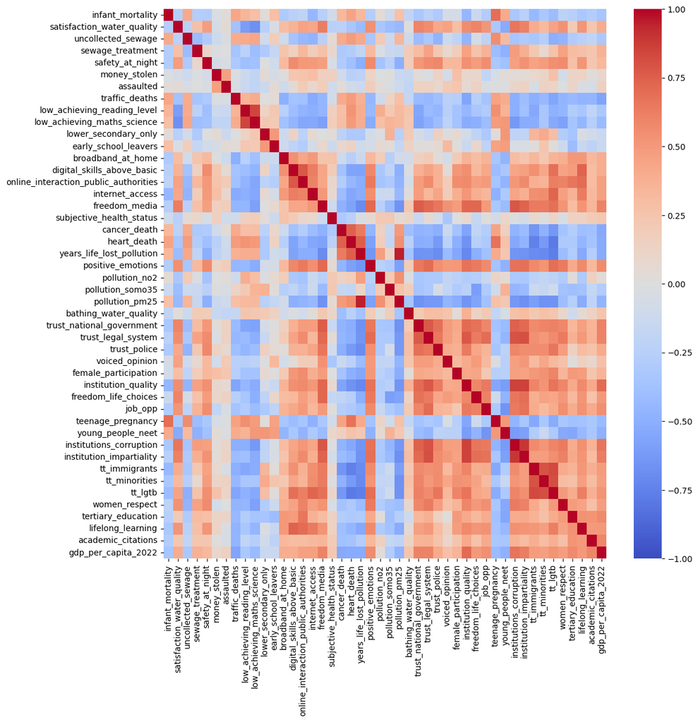

```python
num_col = df.select_dtypes(include='number')

correlation_matrix = num_col.corr()

plt.figure(figsize=(12, 12))
sns.heatmap(correlation_matrix, annot=False, cmap='coolwarm', vmin=-1, vmax=1)

plt.show()
```

**[Figura 01.2]**

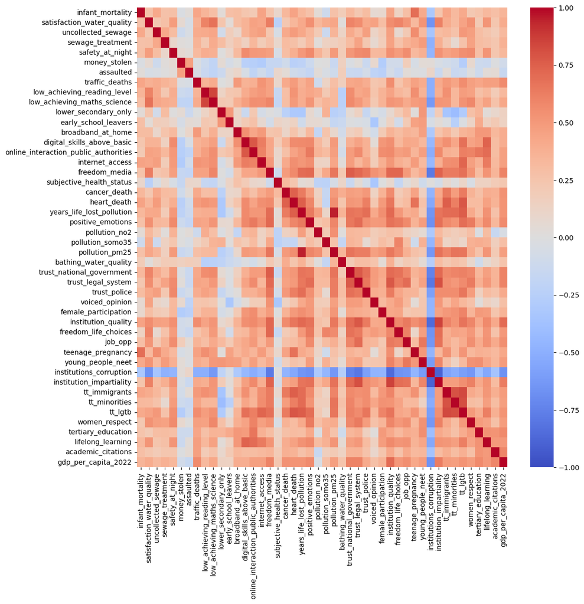

```python
num_col = df_minmax.select_dtypes(include='number')

correlation_matrix = num_col.corr()

plt.figure(figsize=(12, 12))
sns.heatmap(correlation_matrix, annot=False, cmap='coolwarm', vmin=-1, vmax=1)

plt.show()
```

```python
num_col = df_minmax.select_dtypes(include=['float64', 'int64']).columns.tolist()

calculate_bartlett_sphericity(df_minmax[num_col])
```

```
(12691.98953585123, 0.0)
```

```python
calculate_kmo(df_minmax[num_col])
```

```
(array([0.91113371, 0.94458057, 0.86198727, 0.86712125, 0.88333864,
        0.59146788, 0.54655575, 0.9226573 , 0.82794503, 0.8527216 ,
        0.67181132, 0.63337005, 0.78385411, 0.90035619, 0.88740845,
        0.92673913, 0.95432981, 0.49901718, 0.86717901, 0.8603572 ,
        0.86859518, 0.95773948, 0.77342207, 0.79239035, 0.84459341,
        0.81727664, 0.95375926, 0.92577344, 0.88774395, 0.85846325,
        0.92879998, 0.950274  , 0.9221148 , 0.89659565, 0.85294007,
        0.92123469, 0.91508718, 0.93882551, 0.87608969, 0.86447992,
        0.92366193, 0.92276547, 0.83738545, 0.90310549, 0.92506958,
        0.94788907]),
 0.8893298414413183)
```

```python
df_minmax.shape
```

```
(242, 49)
```

### Z score Normalization

```python
# Función para calcular el z-score
def calculate_z_scores(df):
    return (df - df.mean()) / df.std()

# Función de normalización
def normalize_positive(z):
    if z <= -3:
        return 0
    elif -3 < z < 3:
        return ((z + 3) / 6) * 100
    else:
        return 100

def normalize_negative(z):
    if z <= -3:
        return 100
    elif -3 < z < 3:
        return ((3 - z) / 6) * 100
    else:
        return 0
```

```python
# Lista de columnas numéricas
num_cols = df.select_dtypes(include=['float64', 'int64']).columns.tolist()

df_zscore = df.copy()
```

```python
# Iterar sobre indicadores positivos
for col in positively_oriented:
    z_scores = calculate_z_scores(df[col])
    df_zscore[col] = z_scores.apply(normalize_positive)

# Iterar sobre indicadores negativos
for col in negatively_oriented:
    z_scores = calculate_z_scores(df[col])
    df_zscore[col] = z_scores.apply(normalize_negative)

# Iterar sobre el GDP
for col in gdp_index:
    z_scores = calculate_z_scores(df[col])
    df_zscore[col] = z_scores.apply(normalize_positive)  # Normalizando GDP como positivo según la función dada

df_zscore.head()
```

|  | country | nuts_code | region | infant_mortality | satisfaction_water_quality | uncollected_sewage | sewage_treatment | safety_at_night | money_stolen | assaulted | traffic_deaths | low_achieving_reading_level | low_achieving_maths_science | lower_secondary_only | early_school_leavers | broadband_at_home | digital_skills_above_basic | online_interaction_public_authorities | internet_access | freedom_media | subjective_health_status | cancer_death | heart_death | years_life_lost_pollution | positive_emotions | pollution_no2 | pollution_somo35 | pollution_pm25 | bathing_water_quality | … |
| --- | --- | --- | --- | --- | --- | --- | --- | --- | --- | --- | --- | --- | --- | --- | --- | --- | --- | --- | --- | --- | --- | --- | --- | --- | --- | --- | --- | --- | --- | --- |
| 0 | AT | AT11 | Burgenland | 55.903968 | 63.500580 | 55.049893 | 60.280201 | 68.549046 | 46.053873 | 43.655606 | 64.808838 | 48.233335 | 56.172284 | 59.211022 | 49.897848 | 53.933032 | 61.167540 | 57.451041 | 50.103991 | 55.433300 | 56.262554 | 54.796265 | 57.395016 | 55.816165 | 68.441835 | 61.869389 | 36.558076 | 51.605390 | 63.779369 | … |
| 1 | AT | AT12 | Niederösterreich | 47.857852 | 63.500580 | 55.049893 | 60.960878 | 68.549046 | 46.053873 | 43.655606 | 46.103841 | 48.233335 | 56.172284 | 59.649398 | 58.467365 | 53.933032 | 61.167540 | 61.606345 | 50.103991 | 55.433300 | 56.262554 | 58.840223 | 58.930520 | 57.640666 | 68.441835 | 58.796435 | 40.257418 | 54.316930 | 67.772095 | … |
| 2 | AT | AT13 | Wien | 45.558962 | 63.500580 | 55.049893 | 61.065754 | 68.549046 | 46.053873 | 43.655606 | 77.971613 | 48.233335 | 56.172284 | 54.973390 | 44.982978 | 59.884912 | 61.167540 | 66.290356 | 50.103991 | 55.433300 | 56.262554 | 52.996971 | 56.414576 | 54.262538 | 68.441835 | 19.474794 | 41.150958 | 49.099186 | 63.074771 | … |
| 3 | AT | AT21 | Kärnten | 74.295090 | 63.144307 | 55.049893 | 61.166156 | 75.757303 | 43.747221 | 24.022795 | 36.404955 | 48.233335 | 56.172284 | 63.740904 | 58.971454 | 49.876443 | 59.907771 | 56.244929 | 58.525658 | 61.089543 | 56.443016 | 59.481556 | 59.962836 | 58.261728 | 75.885191 | 49.622659 | 36.867565 | 55.487535 | 67.772095 | … |
| 4 | AT | AT22 | Steiermark | 63.950084 | 63.144307 | 55.049893 | 60.978399 | 75.757303 | 43.747221 | 24.022795 | 55.802728 | 48.233335 | 56.172284 | 59.357147 | 58.971454 | 50.375204 | 59.907771 | 57.971487 | 58.525658 | 61.089543 | 56.443016 | 60.862202 | 59.501147 | 54.904826 | 75.885191 | 47.405341 | 36.837699 | 50.111799 | 67.772095 | … |

```python
df_zscore.shape
```

```
(242, 49)
```

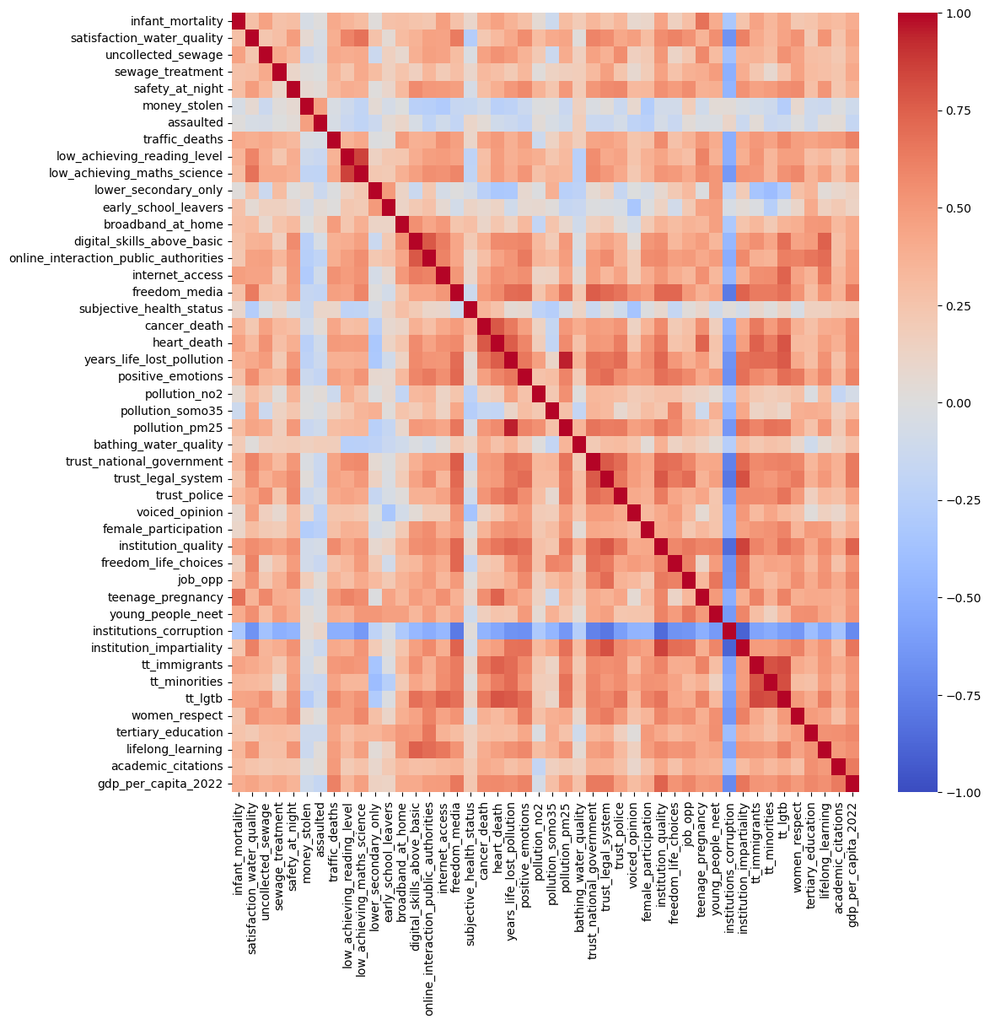

```python
num_col = df_zscore.select_dtypes(include='number')

correlation_matrix = num_col.corr()

plt.figure(figsize=(12, 12))
sns.heatmap(correlation_matrix, annot=False, cmap='coolwarm', vmin=-1, vmax=1)

plt.show()
```

```python
num_cols = df_zscore.select_dtypes(include=['float64', 'int64']).columns.tolist()

calculate_bartlett_sphericity(df_zscore[num_cols])
```

```
(12947.665151125442, 0.0)
```

```python
calculate_kmo(df_zscore[num_cols])
```

```
(array([0.91510202, 0.93897829, 0.88110667, 0.87581478, 0.88486476,
        0.5995638 , 0.56666416, 0.93970845, 0.8220327 , 0.84064945,
        0.67262636, 0.65014035, 0.78727242, 0.90248244, 0.88999208,
        0.9217153 , 0.9485903 , 0.47974361, 0.89713807, 0.86328489,
        0.87614456, 0.95956283, 0.77182718, 0.80845346, 0.85128712,
        0.83671234, 0.95880248, 0.9254551 , 0.8849791 , 0.85352392,
        0.92380506, 0.94461396, 0.92872414, 0.90127535, 0.88170544,
        0.92559085, 0.91684567, 0.94170256, 0.87911413, 0.8671695 ,
        0.92775045, 0.92888429, 0.82641896, 0.90509825, 0.93129302,
        0.93959275]),
 0.8920779818018288)
```

## Guardar datasets normalizados

```python
df_minmax.to_csv('01_normaliza_minmax.csv',
                 index=False)
```

```python
df_zscore.to_csv('01_normaliza_zscore.csv',
                 index=False)
```